# 電力使用量とコロナ

大川 公正

12/17/2021

## 1. はじめに

1. なぜこのテーマを取り上げたのか？
   - 私が1人暮らしをしていて、コロナ前より現在のほうが電気代が 平均1000円～2000円高いと感じたから。
   - 緊急事態宣言により家で過ごす時間が長くなったので、必然的に 電気使用量も増えているのではないかと思ったから。
   - テレビやエアコン、電気をコロナ前よりも使うようになったとい う人がどれだけいるのか気になったから。
   - コロナが流行して、テレワークが進められていたが実際の実施率 はどうなのか気になったから。
   - オンライン授業の普及により、パソコンやタブレットなどの電子 機器を持つ人が多くなり、充電する機会が増えたから。

## 2. 仮説

本研究の仮説は以下の通りである。

> 「電気使用量は、コロナ前に比べると上がっているはずだ」

## 3. 問題の背景

1. 民間企業におけるテレワークの実施状況 民間企業におけるテレワークは、新型コロナ感染症の拡大に伴い、 急速に導入が進んでいる。東京商工リサーチが企業を対象に実施し た調査では、1回目の緊急事態宣言時には17.6％から56.4％へと上 昇し、その後、緊急事態宣言解除後には低下するものの、2回目の 緊急事態宣言時には38.4％に再上昇している（図1)。

図1 企業のテレワーク実施率

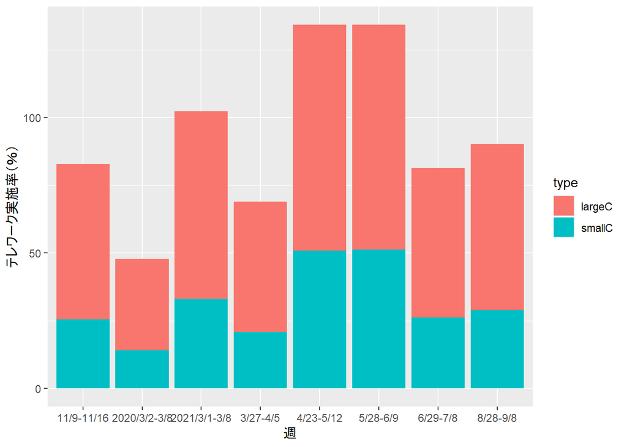

```r
library(ggplot2)
value<-c(33.7,48.0,83.3,83.0,55.2,61.3,57.4,69.2,
          14.1,20.9,50.9,51.2,26.1,29.0,25.5,33.0)
type<-c("largeC","largeC","largeC","largeC","largeC",
        "largeC","largeC","largeC",
        "smallC","smallC","smallC","smallC","smallC",
        "smallC","smallC","smallC")
week<-c("2020/3/2-3/8", "3/27-4/5","4/23-5/12","5/28-6/9",
        "6/29-7/8","8/28-9/8","11/9-11/16","2021/3/1-3/8")

TeleDB<-as.data.frame(cbind(week,value,type))
TeleDB$value<-as.numeric(TeleDB$value)

ggplot(TeleDB)+
  geom_col(aes(x=week,y=value,fill=type))+
  xlab("週")+ylab("テレワーク実施率（％）")
```

（出典）東京商工リサーチ「新型コロナウイルスに関するアンケート」調査（第2～6、8、10、14回）を基に総務省作成

2. また、業種別のテレワーク実施率（2020年11月）を見てみると、実 施率が高いのは、情報通信業（55.7％）、学術研究、専門・技術サ ービス業（43.2％）及び金融業、保険業（30.2％）である。

   一方、医療、介護、福祉（4.3％）、宿泊業、飲食サービス業（11. 1％）及び運輸業、郵便業（11.3％）の実施率は低い。

   このようにテレワークの実施率は、業種ごとにばらつきが生じてい る（図表2）。

図表2 業種別・テレワーク実施率

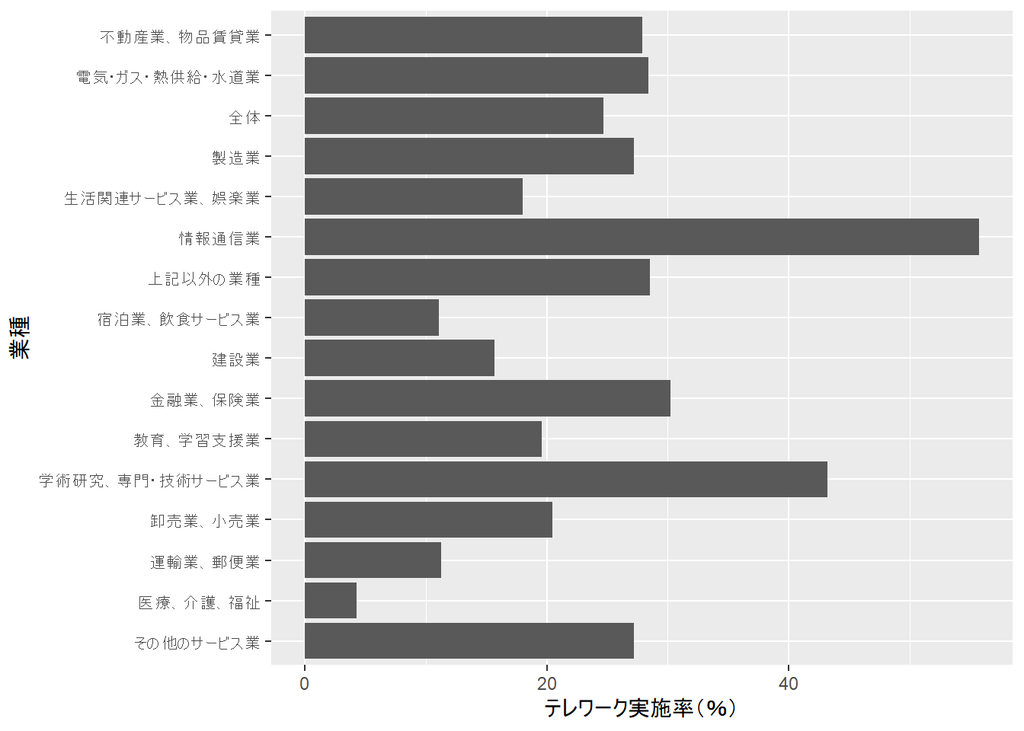

```r
value<-c(24.7,15.7,27.2,28.4,55.7,11.3,20.5,30.2,
          27.9,43.2,11.1,18.0,19.6,4.3,27.2,28.5)
type<-c("全体", "建設業","製造業","電気・ガス・熱供給・水道業",
        "情報通信業","運輸業、郵便業","卸売業、小売業",
        "金融業、保険業","不動産業、物品賃貸業",
        "学術研究、専門・技術サービス業",
        "宿泊業、飲食サービス業","生活関連サービス業、娯楽業",
        "教育、学習支援業","医療、介護、福祉",
        "その他のサービス業","上記以外の業種")

TeleDB2<-as.data.frame(cbind(value,type))
TeleDB2$value<-as.numeric(TeleDB2$value)

ggplot(TeleDB2)+
  geom_col(aes(x=value,y=type))+
  xlab("テレワーク実施率（％）")+ylab("業種")
```

（出典）パーソル総合研究所（2020）「第四回・新型コロナウイルス対策によるテレワークへの影響に関する緊急調査」を基に総務省作成

3. 続いて、地域別のテレワーク実施率（2020年11月）を見てみると、 関東が高く（36.3％）、次いで近畿（20.8％）、東海・北陸・甲信 越（15.9％）が高い。

   東京圏、名古屋圏、大阪圏という三大都市圏が含まれる地域が高く なっており、テレワークの実施率は、地域ごとに差が生じている（ 図表3）。

図表3 地域別・テレワーク実施率

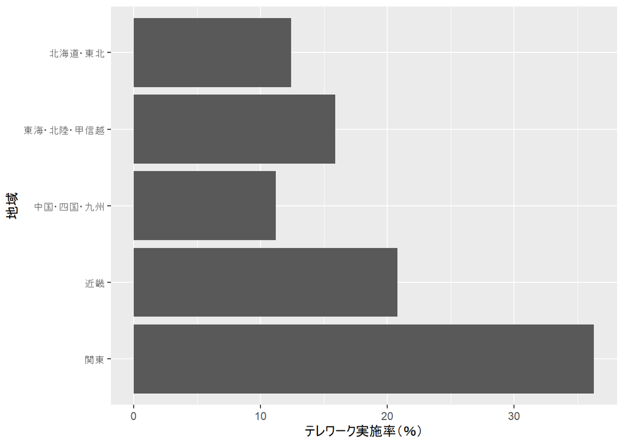

```r
value<-c(12.4,36.3,15.9,20.8,11.2)
type<-c("北海道・東北", "関東",
        "東海・北陸・甲信越","近畿","中国・四国・九州")

TeleDB3<-as.data.frame(cbind(value,type))
TeleDB3$value<-as.numeric(TeleDB3$value)

ggplot(TeleDB3)+
  geom_col(aes(x=value,y=type))+
  xlab("テレワーク実施率（％）")+ylab("地域")
```

（出典）パーソル総合研究所（2020）「第四回・新型コロナウイルス対策によるテレワークへの影響に関する緊急調査」を基に総務省作成

## 4. 分析

### 4.1 データの紹介

- 経済産業省、資源エネルギー庁、電力調査統計表の過去のデータ都 道府県別電力需要実績2018年度、2020年度を使用

### 4.2 分析方法

```r
before = c(29071278,8737908,8481045,14250147,7322507,8108745,15303264,24919481,16737897,16288410,38369901,36263620,78199667,48057333,16922676,11097957,9529620,8185335,5945400,15249002,15201744,29603003,60101338,19895531,12791617,15577875,57236661,37748367,6757744,6264116,3666720,5370636,16315200,19726975,12315933,6137284,7543486,8701628,4144156,31092477,6651333,7756023,11534574,8835635,7052403,9867477,7627920)
after = c(6872699,1432874,1575640,2949805,1166085,1496146,2402000,3830195,2701672,2726335,8875118,7138137,19480640,11451136,2594061,2124849,2360336,1687515,1141376,3585432,3568962,5610008,12152463,3146626,2394075,4095084,13057545,8474795,1958151,1645096,1114512,1378352,3641478,5055533,2465203,1355533,1767062,2239876,1130606,7781445,1408353,2154774,2758480,1934567,1713248,2654017,1351402)

# 帰無仮説： 二つのグループの平均値の差はゼロ

t.test(x = before,y = after,conf.level = 0.95,var.equal = TRUE)
```

```
##
##  Two Sample t-test
##
## data:  before and after
## t = 5.8335, df = 92, p-value = 8.016e-08
## alternative hypothesis: true difference in means is not equal to 0
## 95 percent confidence interval:
##   9359250 19022016
## sample estimates:
## mean of x mean of y
##  18139554   3948921
```

### 4.3 分析結果

```r
DB<-cbind.data.frame(before,after)

summary(DB)
```

```
##      before             after
##  Min.   : 3666720   Min.   : 1114512
##  1st Qu.: 7691972   1st Qu.: 1666306
##  Median :12315933   Median : 2465203
##  Mean   :18139554   Mean   : 3948921
##  3rd Qu.:19811253   3rd Qu.: 3962640
##  Max.   :78199667   Max.   :19480640
```

## 参考文献

総務省 第1部特集デジタルで支える暮らしと経済第3節コロナ禍における企業活動の変化 (https://www.soumu.go.jp/johotsusintokei/whitepaper/ja/r03/html/nd123410.html)